# Estudio de las preferencias de los consumidores de cine

Sección 6 - Grupo 5

04 Junio, 2023

# **Alumnos del grupo**

| **Alumno** | **Código** | **Correo** | **Porcentaje de Trabajo** |
| --- | --- | --- | --- |
| **Alcántara Tacora Sandra Samantha** |  |  |  |
| **Bendezu Gamarra Cesar Abilio** |  |  |  |
| **Chavarria Humareda Javier Omar** |  |  |  |
| **Quevedo Vega Ivonne** |  |  |  |
| **Vento León Omar Alonso** |  |  |  |

# **Introducción**

Antes de la llegada de la pandemia, existía una gran cantidad de usuarios que asistían a las salas de cines ya que muchas veces el cine en general es visto como un buen centro de entretenimiento y sobre todo para pasarlo en familia, esto era muy significativo para la industria cinematográfica. Pero la industria del cine sufrió una crisis económica al declararse la pandemia “COVID-19” en el año 2020, las personas ya no frecuentaban en las salas de los cines debido a las restricciones sanitarias, a pesar de que actualmente se ha vuelto a la normalidad, las salas de cines siguen en una crisis económica. Es por todo lo anteriormente mencionado que el presente proyecto del curso de Estadística y Probabilidad tiene como objetivo identificar el perfil de los usuarios para la mejora de la experiencia en las salas de cine.

### **Tema del proyecto**

Perfil y análisis descriptivo de los usuarios que frecuentan el cine.

### **Relevancia**

Nuestro tema es de suma importancia, pues buscamos el mejoramiento de la experiencia en los cines mediante una encuesta que realizamos a los usuarios que residen en Lima y frecuentan a las salas de cines. Con la información obtenida podemos brindar sugerencias claves y comunicarlo a las empresas como Cineplanet, Cinemark, etc, los resultados que hemos obtenido para que logren obtener un mayor éxito en el servicio al cliente, con la finalidad de llamar mucho más la atención del público objetivo.

### **Objetivos**

##### **General:**

- Identificar el perfil de los usuarios que frecuentan las salas de cine para brindar mejoras en el servicio a partir de las preferencias que tienen los usuarios.

##### **Específicos**

- Conocer si sus usuarios están satisfechos con la experiencia de las salas de cine y/o compra de sus productos.
- Identificar las preferencias de géneros cinematográficos en función a la edad de los usuarios.
- Analizar los factores que pueden influir en la frecuencia de visitas al cine y en la compra de sus productos de dulcería.
- Encontrar los patrones de consumo del público para mejorar la calidad de los servicios en cines.

### **Contexto**

En el presente proyecto evaluaremos una gran cantidad de datos generados en la encuesta que realizamos a personas que residen en Lima y frecuentan las salas de cine, los datos serán analizados utilizando el software RStudio que emplea el lenguaje de programación R, el cual es de mucha utilidad en estudios estadísticos y de probabilidades. Además, cuenta con muchos comandos para obtener descriptores numéricos tales como el promedio, la media, los valores máximos y mínimos obtenidos; incluso tiene la capacidad de realizar gráficos univariados y bivariados, los cuales serán de ayuda para interpretar de una manera más fácil las variables que analizaremos *( Ver Tabla 1)*.

# **Datos**

### **Proceso de recolección de datos**

La recolección de datos se hizo a través de un “Google forms”([Encuesta](https://forms.gle/sg9ARDnVLBoow58B8)). Esto fue realizado de manera grupal con la intervención de cada uno de los miembros de nuestro equipo. Durante todo el proceso, hicimos énfasis en realizar preguntas con respuestas para marcar y en las preguntas para rellenar nos aseguramos de proporcionar restricciones en los números según el rango propuesto para cada variable, para poder obtener datos relacionados con nuestro proyecto.  
Luego se hizo la difusión de la encuesta por redes sociales, siendo la más usada “WhatsApp” con la mayor cantidad de contactos residentes en Lima, pues siempre teníamos en cuenta nuestro público objetivo.

### **Población, muestra y muestreo**

La población en la que nos enfocamos son los **consumidores de la industria cinematográfica que asisten a las salas de cine que viven en el distrito de Lima**. La muestra con la que se trabajó está conformada por **202 personas** (observaciones) las cuales son consumidores de diversas edades y preferencias, donde nuestra unidad muestral es cada persona que suele asistir a las salas de cine en el distrito de Lima. Además, el tipo de muestreo es aleatorio simple para garantizar la representatividad de la muestra.

### **Variables**

Para el proyecto se tienen **17** variables, las cuales son:

[output not shown]

*Tabla 1. Tabla de Variables. Elaboración propia.*

### **Análisis exploratorio**

Previo a la limpieza de datos debemos realizar un análisis exploratorio que consiste en examinar la estructura y componentes del *dataset*.

**1. Leer la data**

```r
DD <- read_csv("Data.csv")
```

**2. Revisar la data**

Con `ncol` y `nrow` podemos tener las dimensiones de la base de datos (filas y columnas)

```
## Los datos presentan 202 observaciones y 18 variables.
```

Después de utilizar el comando `ncol` nos da un resultado de 18 columnas, las cuales nos indica que poseemos 18 variables. Sin embargo, en nuestro proyecto solo haremos uso de 17 variables. Además, se debe tener $202\times18=3636$ (celdas) y todas ellas deben estar llenas.

```
## Hay un total de 3636 datos y 202 observaciones completas.
```

Utilizando `is.na` y `complete.cases` confirmamos que no se encuentran datos faltantes en nuestro dataset.

A continuación hallaremos la variable que no se usará en el estudio haciendo uso de comandos como `str` y `glimpse` que también nos permitirá ver el tipo de variable de la base de datos que asume RStudio.

```r
glimpse(DD)
```

```
## Rows: 202
## Columns: 18
## $ `Marca temporal`                                                <chr> "4/20/…
## $ Edad                                                            <dbl> 19, 20…
## $ `Distrito de residencia`                                        <chr> "Indep…
## $ `Estado ocupacional`                                            <chr> "Estud…
## $ `Presupuesto estimado`                                          <dbl> 30.5, …
## $ `¿Sigue su presupuesto estimado?`                               <chr> "A vec…
## $ `Cine al que va usualmente`                                     <chr> "Cinep…
## $ `¿Es socio del cine al que suele asistir?`                      <chr> "Sí", …
## $ `Días de la semana a la que acostumbra ir al cine`              <chr> "Marte…
## $ `Frecuencias de visitas al cine en un mes`                      <dbl> 10, 7,…
## $ `Número de películas que ha visto más de una vez.`              <dbl> 2, 0, …
## $ `Género cinematográfico de preferencia`                         <chr> "Terro…
## $ `¿Cuánto tiempo demora en ir desde su casa al cine en minutos?` <dbl> 45, 35…
## $ `Precio de las entradas del cine en soles`                      <dbl> 8.5, 6…
## $ `¿Va acompañado al cine?`                                       <chr> "Sí", …
## $ `¿Suele comprar en la dulcería del cine?`                       <chr> "Traig…
## $ `Calidad de los productos de la dulcería`                       <chr> "No co…
## $ `Experiencia general en el cine`                                <chr> "Bueno…
```

```r
str(DD)
```

```
## spc_tbl_ [202 × 18] (S3: spec_tbl_df/tbl_df/tbl/data.frame)
##  $ Marca temporal                                               : chr [1:202] "4/20/2023 8:48:11" "4/20/2023 8:50:31" "4/20/2023 9:01:27" "4/20/2023 9:27:20" ...
##  $ Edad                                                         : num [1:202] 19 20 19 19 19 19 20 19 20 19 ...
##  $ Distrito de residencia                                       : chr [1:202] "Independencia" "Santa Anita" "Los olivos" "Magdalena del mar" ...
##  $ Estado ocupacional                                           : chr [1:202] "Estudia" "Estudia" "Estudia" "Estudia" ...
##  $ Presupuesto estimado                                         : num [1:202] 30.5 9.5 40 70 50 80 12.5 20 40 30 ...
##  $ ¿Sigue su presupuesto estimado?                              : chr [1:202] "A veces" "Sí, siempre" "A veces" "Sí, siempre" ...
##  $ Cine al que va usualmente                                    : chr [1:202] "Cineplanet" "Cineplanet" "Cineplanet" "Cineplanet" ...
##  $ ¿Es socio del cine al que suele asistir?                     : chr [1:202] "Sí" "Sí" "Sí" "No" ...
##  $ Días de la semana a la que acostumbra ir al cine             : chr [1:202] "Martes" "Martes" "Martes" "Martes" ...
##  $ Frecuencias de visitas al cine en un mes                     : num [1:202] 10 7 3 2 2 1 3 1 8 1 ...
##  $ Número de películas que ha visto más de una vez.             : num [1:202] 2 0 15 5 3 2 2 0 1 5 ...
##  $ Género cinematográfico de preferencia                        : chr [1:202] "Terror" "Drama" "Drama" "Romance" ...
##  $ ¿Cuánto tiempo demora en ir desde su casa al cine en minutos?: num [1:202] 45 35 20 20 15 45 90 60 120 10 ...
##  $ Precio de las entradas del cine en soles                     : num [1:202] 8.5 6.5 11 30 17 15 12 15 18 19 ...
##  $ ¿Va acompañado al cine?                                      : chr [1:202] "Sí" "Sí" "Sí" "Sí" ...
##  $ ¿Suele comprar en la dulcería del cine?                      : chr [1:202] "Traigo mis propios productos" "Traigo mis propios productos" "A veces" "Sí" ...
##  $ Calidad de los productos de la dulcería                      : chr [1:202] "No compra" "No compra" "Bueno" "Regular" ...
##  $ Experiencia general en el cine                               : chr [1:202] "Bueno" "Bueno" "Bueno" "Bueno" ...
##  - attr(*, "spec")=
##   .. cols(
##   ..   `Marca temporal` = col_character(),
##   ..   Edad = col_double(),
##   ..   `Distrito de residencia` = col_character(),
##   ..   `Estado ocupacional` = col_character(),
##   ..   `Presupuesto estimado` = col_double(),
##   ..   `¿Sigue su presupuesto estimado?` = col_character(),
##   ..   `Cine al que va usualmente` = col_character(),
##   ..   `¿Es socio del cine al que suele asistir?` = col_character(),
##   ..   `Días de la semana a la que acostumbra ir al cine` = col_character(),
##   ..   `Frecuencias de visitas al cine en un mes` = col_double(),
##   ..   `Número de películas que ha visto más de una vez.` = col_double(),
##   ..   `Género cinematográfico de preferencia` = col_character(),
##   ..   `¿Cuánto tiempo demora en ir desde su casa al cine en minutos?` = col_double(),
##   ..   `Precio de las entradas del cine en soles` = col_double(),
##   ..   `¿Va acompañado al cine?` = col_character(),
##   ..   `¿Suele comprar en la dulcería del cine?` = col_character(),
##   ..   `Calidad de los productos de la dulcería` = col_character(),
##   ..   `Experiencia general en el cine` = col_character()
##   .. )
##  - attr(*, "problems")=<externalptr>
```

Después de ver las variables, sabemos que la primera que se toma en cuenta es la variable “Marca Temporal”, que nos indica la hora que fue llenada la encuesta. Esta columna será removida en la limpieza de datos.

Utilizando el comando `summary` obtendremos un resumen general de la base de datos.

```r
summary(DD)
```

```
##  Marca temporal          Edad       Distrito de residencia Estado ocupacional
##  Length:202         Min.   :15.00   Length:202             Length:202
##  Class :character   1st Qu.:19.00   Class :character       Class :character
##  Mode  :character   Median :20.00   Mode  :character       Mode  :character
##                     Mean   :22.56
##                     3rd Qu.:24.00
##                     Max.   :52.00
##  Presupuesto estimado ¿Sigue su presupuesto estimado? Cine al que va usualmente
##  Min.   :  5.00       Length:202                      Length:202
##  1st Qu.: 30.00       Class :character                Class :character
##  Median : 40.00       Mode  :character                Mode  :character
##  Mean   : 44.05
##  3rd Qu.: 50.00
##  Max.   :120.00
##  ¿Es socio del cine al que suele asistir?
##  Length:202
##  Class :character
##  Mode  :character
##
##
##
##  Días de la semana a la que acostumbra ir al cine
##  Length:202
##  Class :character
##  Mode  :character
##
##
##
##  Frecuencias de visitas al cine en un mes
##  Min.   : 0.00
##  1st Qu.: 1.00
##  Median : 2.00
##  Mean   : 2.96
##  3rd Qu.: 3.75
##  Max.   :15.00
##  Número de películas que ha visto más de una vez.
##  Min.   : 0.000
##  1st Qu.: 2.000
##  Median : 2.000
##  Mean   : 3.354
```

[output cut: 22 more lines]

```
##  Max.   :69.99
##  ¿Suele comprar en la dulcería del cine?
##  Length:202
##  Class :character
##  Mode  :character
##
##
##
##  Calidad de los productos de la dulcería Experiencia general en el cine
##  Length:202                              Length:202
##  Class :character                        Class :character
##  Mode  :character                        Mode  :character
##
##
##
```

Observamos que los nombres de nuestras variables son muy extensos, para ello lo cambiaremos más adelante en nuestra limpieza de datos por unos nombres más cortos y comprensibles según los nombres que pusimos en nuestra tabla de datos.

**3. Revisar el principio y final de la data**

Es necesario ver el principio y final de la base de datos, para tener una idea de qué podría estar fallando o si todo anda con normalidad

| Marca temporal | Edad | Distrito de residencia | Estado ocupacional | Presupuesto estimado | ¿Sigue su presupuesto estimado? | Cine al que va usualmente | ¿Es socio del cine al que suele asistir? | Días de la semana a la que acostumbra ir al cine | Frecuencias de visitas al cine en un mes | Número de películas que ha visto más de una vez. | Género cinematográfico de preferencia | ¿Cuánto tiempo demora en ir desde su casa al cine en minutos? | Precio de las entradas del cine en soles | ¿Va acompañado al cine? | ¿Suele comprar en la dulcería del cine? | Calidad de los productos de la dulcería | Experiencia general en el cine |
| --- | --- | --- | --- | --- | --- | --- | --- | --- | --- | --- | --- | --- | --- | --- | --- | --- | --- |
| 4/20/2023 8:48:11 | 19 | Independencia | Estudia | 30.5 | A veces | Cineplanet | Sí | Martes | 10 | 2 | Terror | 45 | 8.5 | Sí | Traigo mis propios productos | No compra | Bueno |
| 4/20/2023 8:50:31 | 20 | Santa Anita | Estudia | 9.5 | Sí, siempre | Cineplanet | Sí | Martes | 7 | 0 | Drama | 35 | 6.5 | Sí | Traigo mis propios productos | No compra | Bueno |
| 4/20/2023 9:01:27 | 19 | Los olivos | Estudia | 40.0 | A veces | Cineplanet | Sí | Martes | 3 | 15 | Drama | 20 | 11.0 | Sí | A veces | Bueno | Bueno |
| 4/20/2023 9:27:20 | 19 | Magdalena del mar | Estudia | 70.0 | Sí, siempre | Cineplanet | No | Martes | 2 | 5 | Romance | 20 | 30.0 | Sí | Sí | Regular | Bueno |
| 4/20/2023 9:42:24 | 19 | Lurín | Estudia | 50.0 | Sí, siempre | Cineplanet | No | Viernes | 2 | 3 | Comedia | 15 | 17.0 | Sí | Sí | Regular | Bueno |
| 4/20/2023 9:44:16 | 19 | Lurigancho | Estudia | 80.0 | Sí, siempre | Cineplanet | Sí | Viernes | 1 | 2 | Comedia | 45 | 15.0 | Sí | Sí | Bueno | Bueno |

| Marca temporal | Edad | Distrito de residencia | Estado ocupacional | Presupuesto estimado | ¿Sigue su presupuesto estimado? | Cine al que va usualmente | ¿Es socio del cine al que suele asistir? | Días de la semana a la que acostumbra ir al cine | Frecuencias de visitas al cine en un mes | Número de películas que ha visto más de una vez. | Género cinematográfico de preferencia | ¿Cuánto tiempo demora en ir desde su casa al cine en minutos? | Precio de las entradas del cine en soles | ¿Va acompañado al cine? | ¿Suele comprar en la dulcería del cine? | Calidad de los productos de la dulcería | Experiencia general en el cine |
| --- | --- | --- | --- | --- | --- | --- | --- | --- | --- | --- | --- | --- | --- | --- | --- | --- | --- |
| ########## | 21 | Miraflores | Estudia | 60 | Sí, siempre | Cinemark | Sí | Viernes | 2 | 3 | Comedia | 10 | 18 | Sí | A veces | Regular | Bueno |
| ########## | 28 | San Borja | Estudia | 45 | Sí, siempre | Cinépolis | Sí | Lunes | 1 | 5 | Acción | 25 | 15 | Sí | Sí | Regular | Excelente |
| ########## | 26 | Breña | Trabaja | 55 | A veces | Cinemark | Sí | Martes | 3 | 5 | Romance | 10 | 18 | Sí | Sí | Excelente | Excelente |
| ########## | 19 | El Agustino | Estudia y trabaja | 30 | Sí, siempre | Cineplanet | Sí | Viernes | 1 | 10 | Aventura | 45 | 10 | A veces | A veces | Regular | Bueno |
| ########## | 20 | San Juan de Miraflores | Estudia | 20 | A veces | Cineplanet | No | Viernes | 1 | 4 | Comedia | 30 | 12 | Sí | A veces | Regular | Bueno |
| ########## | 18 | San Miguel | Estudia | 50 | A veces | Cineplanet | No | Jueves | 3 | 3 | Terror | 30 | 25 | Sí | Sí | Bueno | Excelente |

### **Limpieza de datos**

**1. Eliminando la variable “Marca Temporal”**

```r
DD1 <- DD %>%
  select(-"Marca temporal")
```

**2. Renombrando las variables**

```r
DD1 = dplyr::rename(DD1,
               Edad="Edad",
               Distrito="Distrito de residencia",
               Estadocupacional="Estado ocupacional",
               Presupuesto="Presupuesto estimado",
               Presupuestofinal = "¿Sigue su presupuesto estimado?",
               Cine ="Cine al que va usualmente",
               Socio="¿Es socio del cine al que suele asistir?",
               Dias ="Días de la semana a la que acostumbra ir al cine",
               Frecuencia = "Frecuencias de visitas al cine en un mes",
               Vistas = "Número de películas que ha visto más de una vez.",
               Genero ="Género cinematográfico de preferencia",
               Viaje = "¿Cuánto tiempo demora en ir desde su casa al cine en minutos?",
               Entradas = "Precio de las entradas del cine en soles",
               Acompañamiento ="¿Va acompañado al cine?",
               Confiteria ="¿Suele comprar en la dulcería del cine?",
               Calidad ="Calidad de los productos de la dulcería",
               Satisfacción = "Experiencia general en el cine")
```

Verificando los nombres de las variables

```r
names(DD1)
```

```
##  [1] "Edad"             "Distrito"         "Estadocupacional" "Presupuesto"
##  [5] "Presupuestofinal" "Cine"             "Socio"            "Dias"
##  [9] "Frecuencia"       "Vistas"           "Genero"           "Viaje"
## [13] "Entradas"         "Acompañamiento"   "Confiteria"       "Calidad"
## [17] "Satisfacción"
```

**3. Recategorizando**

Nos aseguraremos de que las variables sean numéricas discretas, es decir, no podrán aceptar decimales.

```r
DD1$Edad <- as.integer(DD1$Edad)
DD1$Frecuencia <- as.integer(DD1$Frecuencia)
DD1$Vistas <- as.integer(DD1$Vistas)
DD1$Viaje <- as.integer(DD1$Viaje)
```

Transformaremos los datos categóricos a factor para que queden mejor definidas.

```r
DD1$Calidad <- factor(DD1$Calidad)
DD1$Presupuestofinal <- factor(DD1$Presupuestofinal)
DD1$Satisfacción <- factor(DD1$Satisfacción)
DD1$Distrito <- factor(DD1$Distrito)
DD1$Estadocupacional <- factor(DD1$Estadocupacional)
DD1$Socio <- factor(DD1$Socio)
DD1$Cine <- factor(DD1$Cine)
DD1$Dias <- factor(DD1$Dias)
DD1$Confiteria <- factor(DD1$Confiteria)
DD1$Acompañamiento <- factor(DD1$Acompañamiento)
DD1$Genero <- factor(DD1$Genero)
```

Visualizaremos que se cumplan con los comandos *“str”* y *“summary”*:

```r
str(DD1)
```

```
## tibble [202 × 17] (S3: tbl_df/tbl/data.frame)
##  $ Edad            : int [1:202] 19 20 19 19 19 19 20 19 20 19 ...
##  $ Distrito        : Factor w/ 38 levels "Ancón","Ate",..: 13 34 18 21 20 19 29 3 18 3 ...
##  $ Estadocupacional: Factor w/ 4 levels "Estudia","Estudia y trabaja",..: 1 1 1 1 1 1 1 1 1 1 ...
##  $ Presupuesto     : num [1:202] 30.5 9.5 40 70 50 80 12.5 20 40 30 ...
##  $ Presupuestofinal: Factor w/ 3 levels "A veces","No, nunca",..: 1 3 1 3 3 3 1 3 1 3 ...
##  $ Cine            : Factor w/ 5 levels "Cinemark","Cineplanet",..: 2 2 2 2 2 2 4 2 2 2 ...
##  $ Socio           : Factor w/ 2 levels "No","Sí": 2 2 2 1 1 2 1 1 1 1 ...
##  $ Dias            : Factor w/ 7 levels "Domingo","Jueves",..: 4 4 4 4 7 7 7 7 1 1 ...
##  $ Frecuencia      : int [1:202] 10 7 3 2 2 1 3 1 8 1 ...
##  $ Vistas          : int [1:202] 2 0 15 5 3 2 2 0 1 5 ...
##  $ Genero          : Factor w/ 10 levels "Acción","Aventura",..: 10 5 5 8 4 4 4 9 9 1 ...
##  $ Viaje           : int [1:202] 45 35 20 20 15 45 90 60 120 10 ...
##  $ Entradas        : num [1:202] 8.5 6.5 11 30 17 15 12 15 18 19 ...
##  $ Acompañamiento  : Factor w/ 3 levels "A veces","No",..: 3 3 3 3 3 3 3 1 2 2 ...
##  $ Confiteria      : Factor w/ 4 levels "A veces","No",..: 4 4 1 3 3 3 4 4 2 2 ...
##  $ Calidad         : Factor w/ 6 levels "Bueno","Excelente",..: 4 4 1 6 6 1 3 4 1 4 ...
##  $ Satisfacción    : Factor w/ 5 levels "Bueno","Excelente",..: 1 1 1 1 1 1 1 5 1 5 ...
```

```r
summary(DD1)
```

```
##       Edad                         Distrito            Estadocupacional
##  Min.   :15.00   Barranco              : 16   Estudia          :120
##  1st Qu.:19.00   Chorrillos            : 15   Estudia y trabaja: 44
##  Median :20.00   Miraflores            : 12   Ninguno          :  5
##  Mean   :22.56   Santiago de Surco     : 11   Trabaja          : 33
##  3rd Qu.:24.00   San Juan de Lurigancho:  9
##  Max.   :52.00   Ate                   :  8
##                  (Other)               :131
##   Presupuesto        Presupuestofinal         Cine     Socio           Dias
##  Min.   :  5.00   A veces    :113     Cinemark  : 21   No:129   Domingo  :32
##  1st Qu.: 30.00   No, nunca  : 16     Cineplanet:125   Sí: 73   Jueves   :17
##  Median : 40.00   Sí, siempre: 73     Cinépolis : 20            Lunes    :12
##  Mean   : 44.05                       CineStar  : 29            Martes   :35
##  3rd Qu.: 50.00                       UVK       :  7            Miércoles:15
##  Max.   :120.00                                                 Sábado   :18
##                                                                 Viernes  :73
##    Frecuencia        Vistas            Genero       Viaje
##  Min.   : 0.00   Min.   : 0.000   Comedia :51   Min.   : 10.00
##  1st Qu.: 1.00   1st Qu.: 2.000   Acción  :50   1st Qu.: 20.00
##  Median : 2.00   Median : 2.000   Romance :32   Median : 30.00
##  Mean   : 2.96   Mean   : 3.351   Drama   :18   Mean   : 37.57
##  3rd Qu.: 3.75   3rd Qu.: 4.000   Terror  :17   3rd Qu.: 45.00
##  Max.   :15.00   Max.   :20.000   Suspenso:11   Max.   :180.00
##                                   (Other) :23
##     Entradas     Acompañamiento                        Confiteria
##  Min.   : 5.00   A veces: 78    A veces                     :76
##  1st Qu.:14.50   No     : 21    No                          :22
##  Median :17.00   Sí     :103    Sí                          :74
##  Mean   :18.15                  Traigo mis propios productos:30
##  3rd Qu.:20.00
##  Max.   :69.99
##
##       Calidad      Satisfacción
##  Bueno    :59   Bueno    :112
##  Excelente:18   Excelente: 40
##  Malo     : 9   Malo     :  4
##  No compra:43   Pésimo   :  1
##  Pésimo   : 3   Regular  : 45
##  Regular  :70
##
```

**4. Calculando el tamaño efectivo de las muestras**

```
## Tamaño efectivo de las variables:
## Edad: 202
```

```
## Distrito: 202
```

```
## Estadocupacional: 202
```

```
## Presupuesto: 202
```

```
## Presupuestofinal: 202
```

```
## Cine: 202
```

```
## Socio: 202
```

```
## Dias: 202
```

```
## Frecuencia: 202
```

```
## Vistas: 202
```

```
## Genero: 202
```

```
## Viaje: 202
```

```
## Entradas: 202
```

```
## Acompañamiento: 202
```

```
## Confiteria: 202
```

```
## Calidad: 202
```

```
## Satisfacción: 202
```

```
## Por lo tanto la proporción de las observaciones válidas de la muestra total es de: 100 %
```

**5. Asegurando que las variables sean prolijas**

Para verificar que la base de datos sea prolija, es decir, tenga una observación por fila y una variable por columna, utilizamos el comando `dim`, que nos arrojará la cantidad de observaciones las cuales deben ser 202 y la cantidad de columnas las cuales deben ser 17 de acuerdo a la cantidad de variables.

```
## Se tienen las siguientes dimensiones en el dataset actual: 202 17
```

Ahora, aseguraremos que el dataset tenga un valor entre las intersecciones entre filas y columnas, las cuales nos debe dar un total de 3434 datos en total.

```
## Hay un total de 3434 datos en el dataset actual.
```

Finalmente, se puede afirmar que la base de datos está limpia. Esto se debe a que ahora ya es posible realizar los gráficos necesarios para el desarrollo del estudio. Asimismo, hay coherencia en cuanto a las respuestas obtenidas.

# **Análisis Descriptivo**

Encuestamos un total de 202 usuarios del cine que se encuentran en un rango de 15 a 55 años, acuden a cines que están en el departamento de Lima. Asimismo, la unidad muestral fue cada uno de los usuarios que cumplen con esos requisitos. Ahora, realizaremos el análisis descriptivo de las variables obtenidas considerando a la muestra mencionada.

## **Análisis Univariado**

### **Variable *Edad***

**Descriptores numéricos:**

- Mínimo, mediana, media y máximo

```
##    Min. 1st Qu.  Median    Mean 3rd Qu.    Max.
##   15.00   19.00   20.00   22.56   24.00   52.00
```

**Descriptor gráfico:**

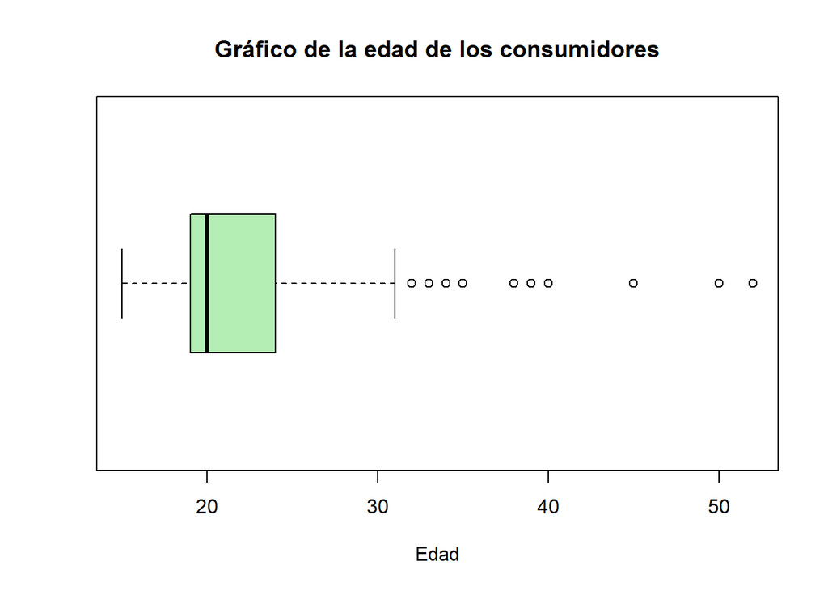

*Gráfico 1. Gráfico de Edad. Elaboración propia.*

```
## Los datos atípicos son: 39 33 33 33 40 35 35 32 50 34 52 35 38 45 32 34 32 45
```

```
## El coeficiente de variación es: 26.44 %
```

```
## El coeficiente de variación es: 0.31 %
```

**Análisis:**

En este caso observamos que en *promedio* la edad de los consumidores es de 22.56 años. Es decir, son jóvenes adultos, además el *primer cuartil* nos indica que el primer 25% de los consumidores tienen o están un rango de 15-19 años. La *mediana* es 20 años y el *tercer cuartil* es 24 años, lo que indicaría que hasta el primer 75% de consumidores tienen una edad de 24 años. Todos estos descriptores numéricos nos muestran que la gran mayoría de consumidores son adolescentes y jóvenes adultos que posiblemente se deba a que tengan mayor tiempo para actividades de entretenimiento. Finalmente, sabemos que el *máximo* es 52 años y por el gráfico obtenemos que los datos atípicos van desde los 32 años para adelante, los cuales hacen que los datos sean heterogéneos ya que el coeficiente de variación resulta en un 26.44%, cifra que contrasta en exceso al coeficiente de variación cuando se retiran los datos atípicos que es de un 0.31%.

### **Variable *Presupuesto***

**Descriptores numéricos:**

- Mínimo, mediana, media y máximo

```
##    Min. 1st Qu.  Median    Mean 3rd Qu.    Max.
##    5.00   30.00   40.00   44.05   50.00  120.00
```

**Descriptor gráfico:**

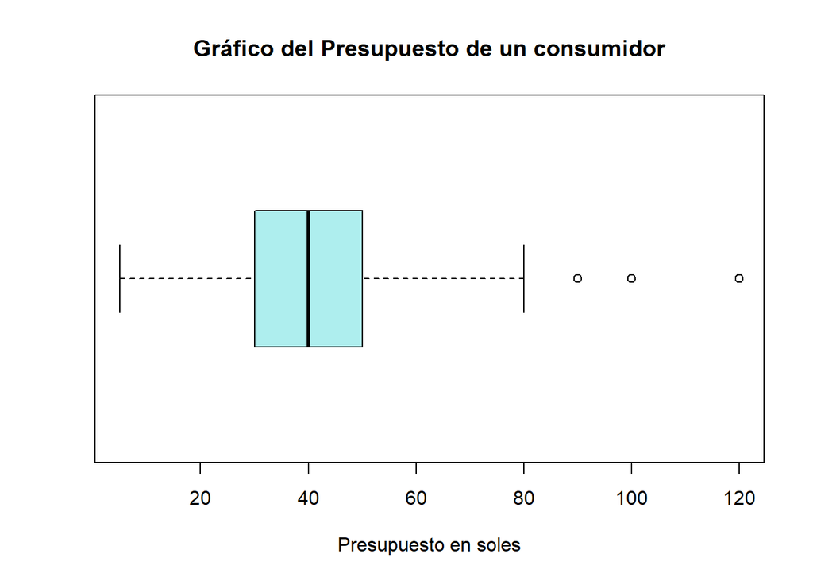

*Gráfico 2. Gráfico de Presupuesto. Elaboración propia.*

```
## Los datos atípicos son: 100 100 90 100 100 100 100 100 100 100 100 100 100 120 90 100 120 100 100 100 100
```

```
## El coeficiente de variación es: 55.56 %
```

```
## El coeficiente de variación es: 0.34 %
```

**Análisis:**

En este caso observamos que en *promedio* del presupuesto para una visita al cine es de 44.05 soles y la *mediana* es de 40 soles, lo que indica que la distribución de la variable es sesgada a la derecha. Además, a partir del *tercer cuartil*, después del 75% de los datos, hasta el valor *máximo* que es 120, se pueden apreciar en el gráfico que se presentan varios datos atípicos. Los cuales influyen en la precisión de los datos ya que tenemos un 55.56% de porcentaje en el coeficiente de variación, mientras que si no consideramos los datos atípicos, los resultados serían homogéneos con un 0.34% de coeficiente de variación. Esto puede deberse a que la gran mayoría al ser jóvenes no cuentan con mucho presupuesto y que los pocos adultos que acuden al cine cuentan con más dinero para el presupuesto en una sola salida al cine.

### **Variable *Cine***

**Descriptor Gráfico:**

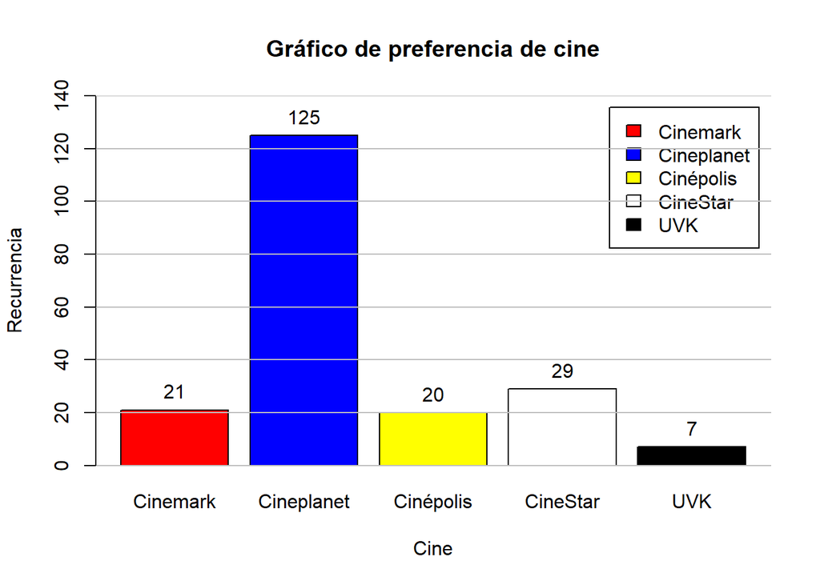

*Gráfico 3. Gráfico de Cine. Elaboración propia.*

**Análisis:**

El *Gráfico 3* nos indica que el establecimiento Cineplanet es el más concurrido, sobrepasando por más del 100% en recurrencia a comparación de los demás cines.

### **Variable *Días***

**Descriptor Gráfico:**

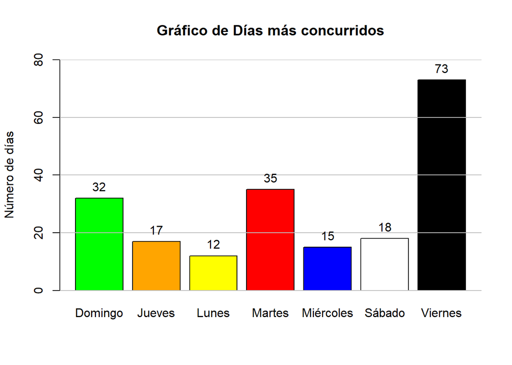

*Gráfico 4. Gráfico de Días. Elaboración propia.*

**Análisis:**

En el *Gráfico 4* podemos observar que el viernes es el día más concurrido en los cines, lo que puede deberse a que es próximo al fin de semana.

### **Variable *Frecuencia***

**Descriptor Gráfico:**

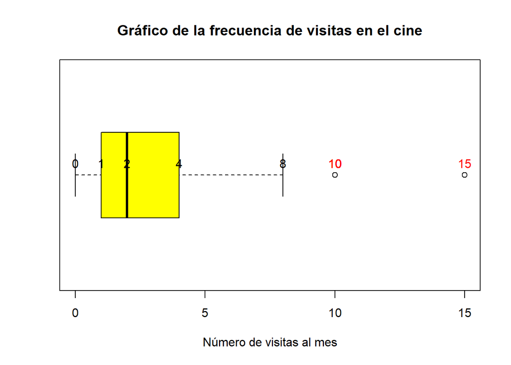

*Gráfico 5. Gráfico de Frecuencia. Elaboración propia.*

**Análisis:**

Para la variable Frecuencia la *mediana* es de 2 visitas al mes y según nos indica la gráfica la distribución de la variable es sesgada a la derecha ya que el grosor de la caja a la derecha de la línea negra es mayor que el grosor de la parte izquierda. Lo que se debe a que hay algunos consumidores que van constantemente al cine en el mes, siendo que la *máxima* cantidad de veces que va un consumidor es de 15 visitas por mes.

### **Variable *Entradas***

**Descriptores numéricos:**

- Mínimo, mediana, media y máximo

```
##    Min. 1st Qu.  Median    Mean 3rd Qu.    Max.
##    5.00   14.50   17.00   18.15   20.00   69.99
```

**Descriptor Gráfico:**

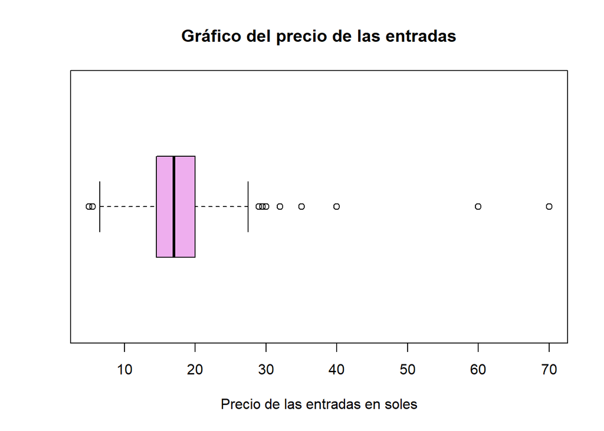

*Gráfico 6. Gráfico de Entradas. Elaboración propia.*

```
## Los datos atípicos son: 30 5 30 30 30 31.99 29 5.5 30 30 40 35 29.99 29.5 32 30 60 69.99 30 30 35
```

```
## El coeficiente de variación es: 42.86 %
```

```
## El coeficiente de variación es: 0.32 %
```

**Análisis:**

### **Variable *Calidad***

**Descriptor Gráfico:**

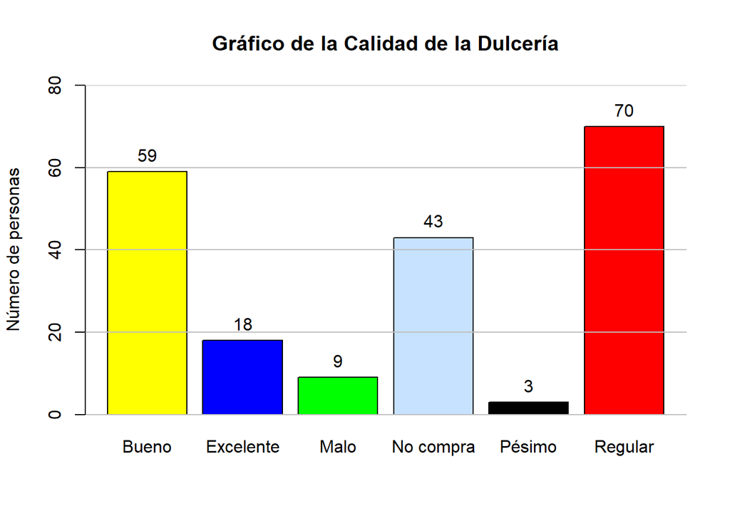

*Gráfico 7. Gráfico de Calidad. Elaboración propia.*

**Análisis:**

El *Gráfico 7* nos indica que a la mayoría de los usuarios les parece regular la calidad de los productos en las dulcerías de los cine a cual acuden más.

### **Variable *Satisfacción***

**Descriptor Gráfico:**

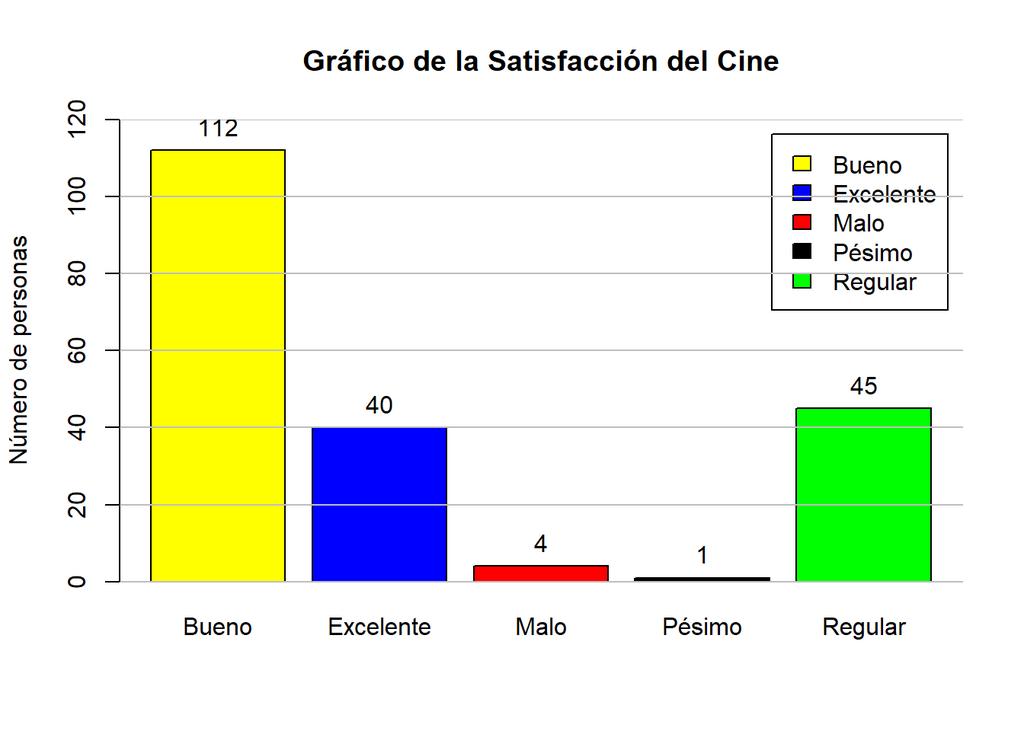

*Gráfico 8. Gráfico de Satisfacción. Elaboración propia.*

**Análisis:**

En el *Gráfico 8* podemos observar que en general, se sienten satisfechos con la experiencia en el cine al que acuden más, ya que son muy pocas las personas a las que le parecen los servicios del establecimiento como malos o pésimos en comparación con la cantidad de personas a quienes les parecen bueno o excelente el servicio.

## **Análisis Bivariado**

### **Edad vs. Presupuesto**

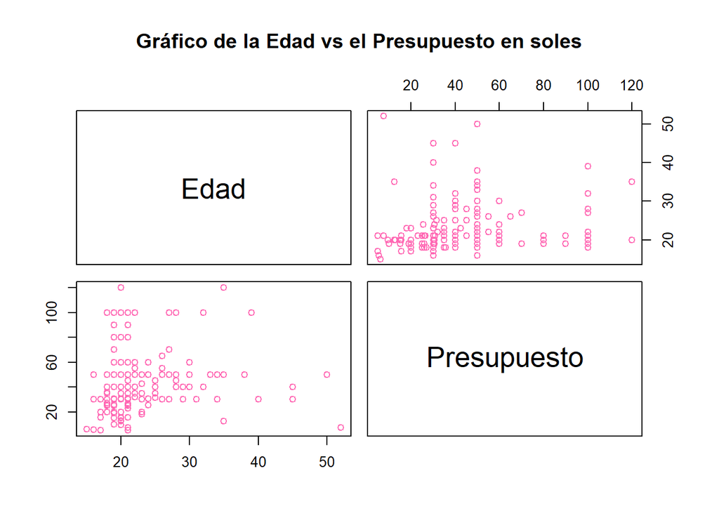

*Gráfico 9. Gráfico de Edad vs Presupuesto. Elaboración propia.*

En el gráfico se visualiza que la gran mayoría de jóvenes presentan menor presupuesto a la hora de ir al cine, mientras que algunos adultos entre los 30 y 40 años pueden gastar un poco más, sabiendo que el presupuesto abarca el costo de la entrada y costos adicionales como comida, podemos decir que muy pocas personas en el rango de edad de nuestra muestra gasta su dinero en la dulcería del cine o en la compra de otros productos adicionales.

### **Acompañamiento vs. Presupuesto**

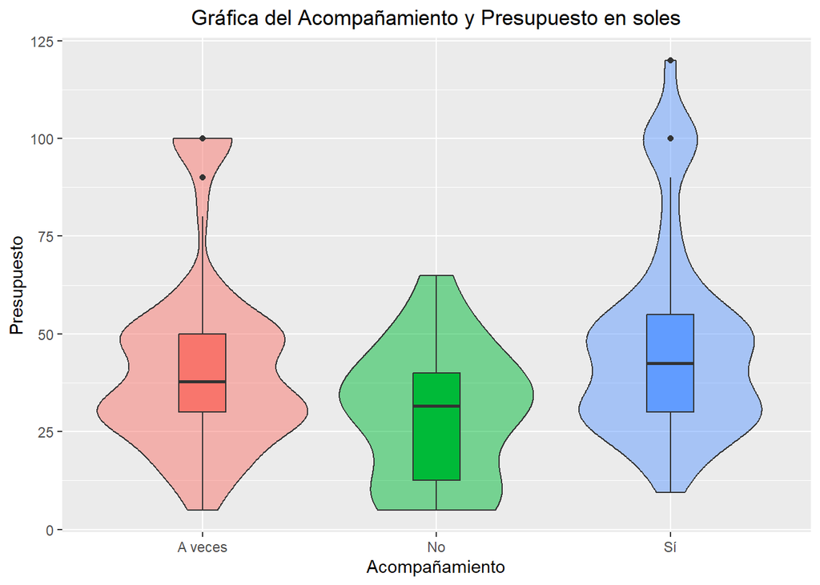

*Gráfico 10. Gráfico de Acompañamiento vs Presupuesto. Elaboración propia.*

Del gráfico podemos sacar las siguientes conclusiones:

- Los consumidores prefieren ir acompañados al cine.
- La gran mayoría va acompañado al cine y por lo tanto, lleva un mayor presupuesto.
- Los que van solos al cine presentan el rango más bajo de presupuesto.

Según lo visto en el *Gráfico 9* podríamos decir que la gran mayoría que son los jóvenes prefieren ir acompañados al cine, mientras que los consumidores entre 40 y 50 años no suelen ir acompañados y es por esa razón que presentan el menor presupuesto que abarca solamente sus entradas al cine.

### **Presupuesto vs. Presupuesto final**

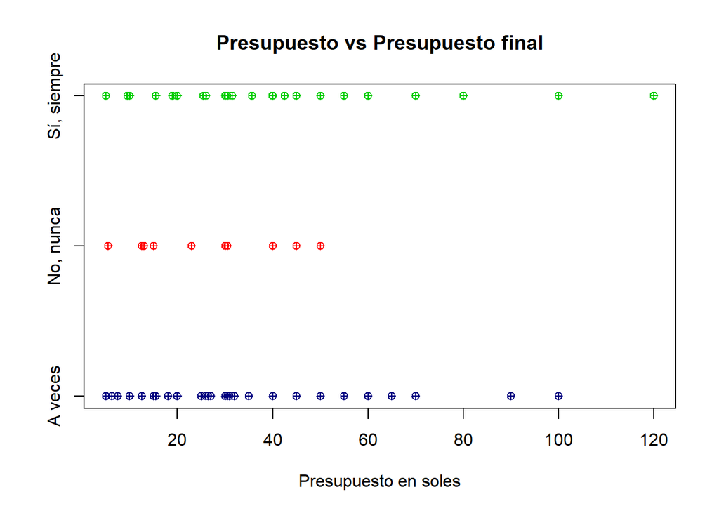

*Gráfico 11. Gráfico de Presupuesto vs Presupuesto final. Elaboración propia.*

### **Confitería vs. Calidad**

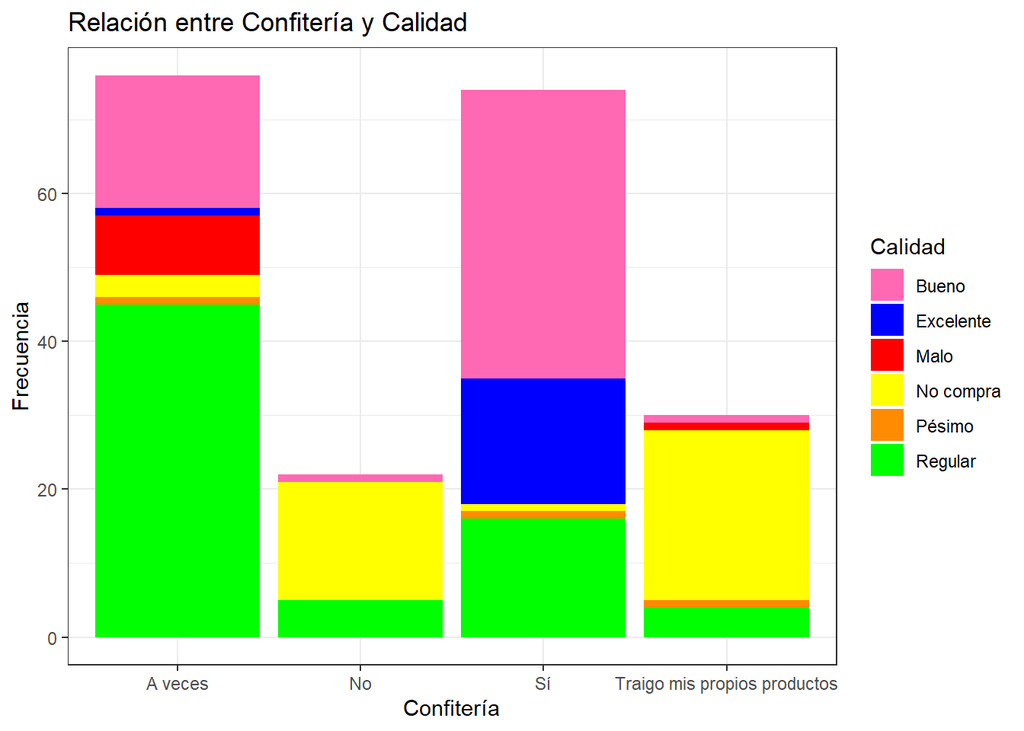

*Gráfico 12. Gráfico de Confitería vs Calidad. Elaboración propia.*

En el gráfico podemos obtener las siguientes conclusiones:

- Son muchos los usuarios que compran en la confitería del cine o que a veces compran ahí.
- La gran mayoría que compra lo hacen porque los productos les parecen buenos o excelentes.
- Los que compran a veces lo hacen porque la calidad del producto les parece regular.

### **Cine vs. Calidad**

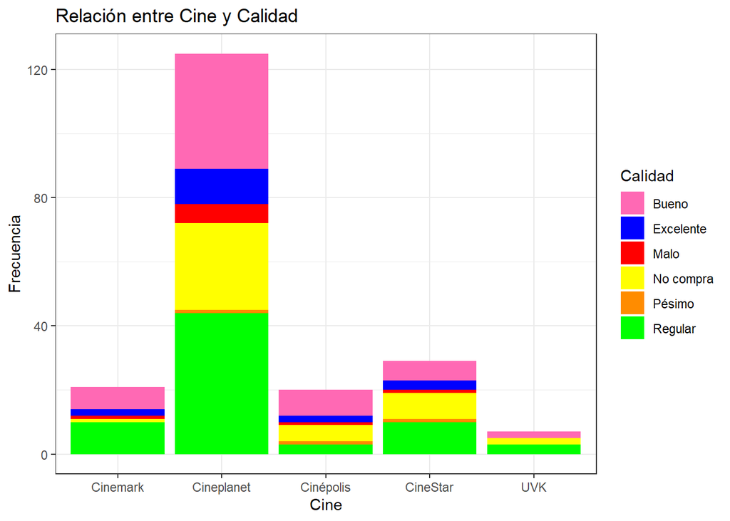

- Los consumidores de Cineplanet opinan que la calidad de los productos son buenos y/o regulares.
- La opinión de los consumidores de productos en Cinépolis en su mayoría tiene una buena comparación entre las opiniones de pésimas y/o malas.

### **Cine vs. Frecuencia**

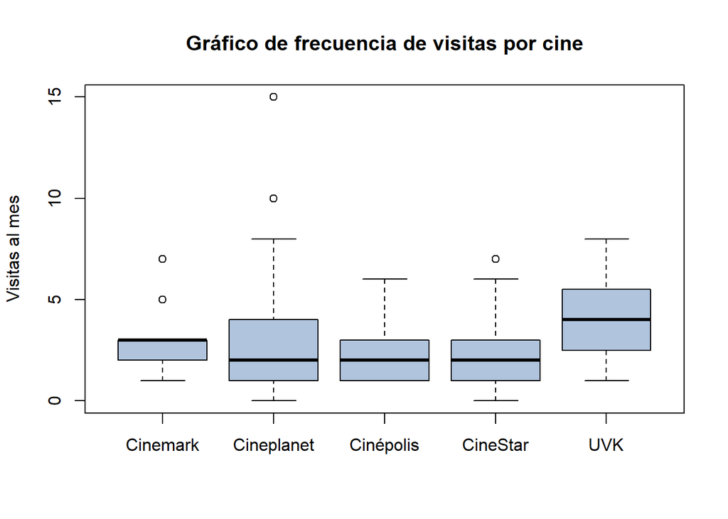

*Gráfico 13. Gráfico de Cine vs Frecuencia. Elaboración propia.*

### **Edad vs. Género**

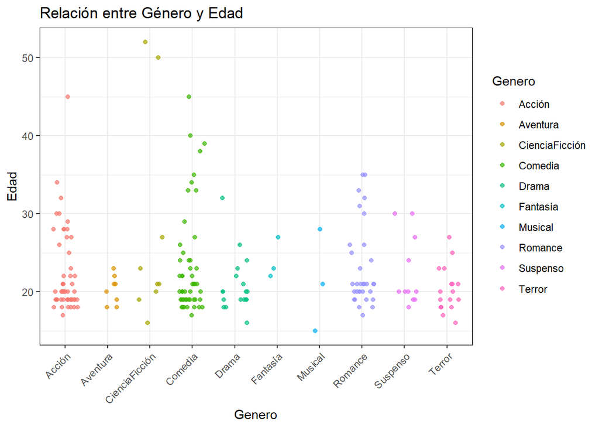

*Gráfico 14. Gráfico de Género vs Edad. Elaboración propia.*

### **Distrito vs. Satisfacción**

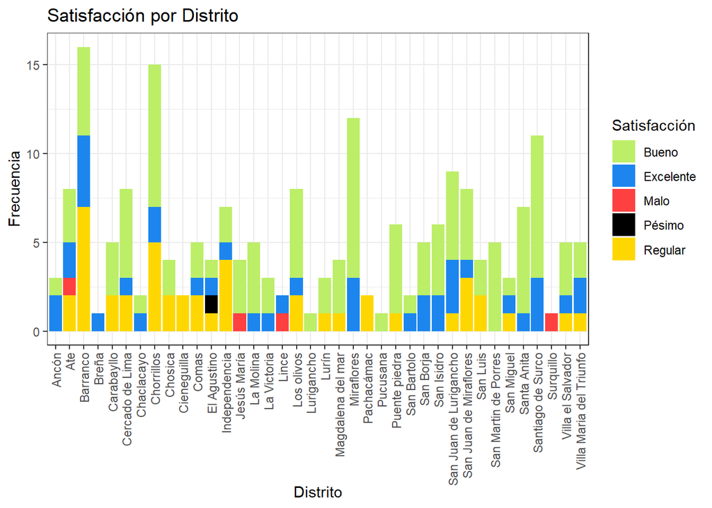

*Gráfico 15. Gráfico de Distrito vs Satisfacción. Elaboración propia.*

Según el presente gráfico podemos concluir que:

- Los distritos más concurridos son de los distritos de Barranco, Chorrillos, Miraflores y Santiago de Surco.
- Los cines con mejor calificación son los que se encuentran en Chorrillos y Miraflores. Miraflores obteniendo el mejor puntaje al no poseer ninguna calificación negativa.
- Son pocos los cines que tienen baja percepción de satisfacción, siendo el de Surquillo el peor en satisfacción.